# Simple Linear Regression

[figure not shown]

```r
# Load libraries
library(tidyverse)
library(pander)
library(ggplot2)
library(dplyr)


# Read in the dataset
billionaires <- read.csv("Billionaires.csv", header=TRUE)
```

## Introduction

Well now, the data collected is about famous rich people. It tells us how much dough they’re packin’ in their pockets, also known as their net worth. And let’s not forget age, cause that plays a role too. The older you are, the more time you got to accumulate that fortune, so it’s likely the older fellers got more coin than the younger bucks.

$$Net Worth = β0 + β1 * Age + ε$$

## Hypothesis

I hypothesize that there is a relationship between age and net worth among rich people on the data collected.

Is there a relationship between age and net worth among billionaires?

$$H_0: \beta_1 = 0 \\
H_a: \beta_1 \neq 0\\
\alpha = 0.05$$

$$H_0: \text{Age is not a predictor of net worth among billionaires}$$

$$H_a: \text{Age is a significant predictor of net worth among
billionaires}$$

To answer this question, we can use a simple linear regression model to determine whether there is a linear relationship between age and net worth in this dataset. The model can be expressed as:

$$\underbrace{Y_i}_\text{Net Worth} = \beta_0 + \beta_1
\underbrace{X_i}_\text{Age} + \epsilon_i \quad \text{where} \ \epsilon_i
\sim N(0, \sigma^2)$$

## Analysis

Well now, let’s get to the heart of this analysis. We’ll start by examining the **connection between age and net worth** by plotting them together on a **scatter plot**. This way, we can see how these variables interact visually and spot any peculiarities or oddities.

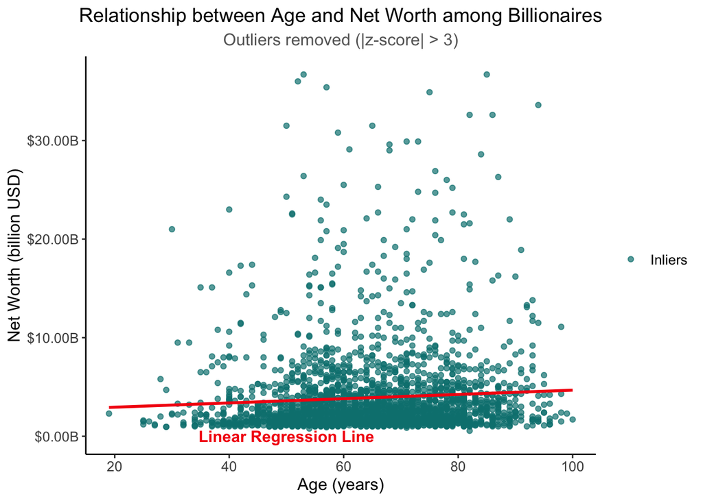

```r
# Read the data into R
billionaires <- read.csv("billionaires.csv")

# Fit a linear regression model to the data
billionaires_regression <- lm(NetWorth ~ Age, data = billionaires)

# Calculate the z-score for net worth
billionaires$z_score <- abs(scale(billionaires$NetWorth))

# Filter out the outliers
billionaires_filtered <- filter(billionaires, z_score <= 3)

# Create a scatterplot with outliers removed and linear regression line
ggplot(billionaires_filtered, aes(x = Age, y = NetWorth)) +
  geom_point(aes(color = "Inliers"), size = 1.5, alpha = 0.7) +
  geom_smooth(method = "lm", se = FALSE, color = "#F41711", size = 1) +
  annotate("text", x = 50, y = 80, label = "Linear Regression Line",
           size = 4, fontface = "bold", color = "#F41711") +
  theme_classic() +
  labs(x = "Age (years)", y = "Net Worth (billion USD)", color = ' ') +
  ggtitle("Relationship between Age and Net Worth among Billionaires") +
  scale_y_continuous(labels = scales::dollar_format(scale = 1e-9, suffix = "B")) +
  scale_color_manual(values=c("#008080")) +
  theme(plot.title = element_text(size = 14, hjust = 0.5),
        plot.subtitle = element_text(size = 12, hjust = 0.5, color = "grey40"),
        axis.title = element_text(size = 12),
        axis.text = element_text(size = 10),
        legend.title = element_blank(),
        legend.text = element_text(size = 10)) +
  labs(subtitle = "Outliers removed (|z-score| > 3)")
```

Well, let me tell you about that fancy code summary(billionaires_regression) - it gives a summary of a linear regression model. It’s got all kinds of info on the coefficients, t-statistics, R-squared value, and more. It’s a powerful tool for evaluating the fit and significance of a linear regression model:

```r
pander(summary(billionaires_regression))
```

|  | Estimate | Std. Error | t value | Pr(>\|t\|) |
| --- | --- | --- | --- | --- |
| **(Intercept)** | 2.821e+09 | 1.062e+09 | 2.656 | 0.007954 |
| **Age** | 31813247 | 16050062 | 1.982 | 0.04758 |

Fitting linear model: NetWorth ~ Age

| Observations | Residual Std. Error | $R^2$ | Adjusted $R^2$ |
| --- | --- | --- | --- |
| 2438 | 1.065e+10 | 0.00161 | 0.0012 |

## Conclusion

The summary output of the linear regression model reveals some interesting findings regarding the relationship between age and net worth among billionaires.

The coefficients section indicates that age is a statistically significant predictor of net worth, as indicated by the p-value of 0.04758, which is less than 0.05, indicating that age is a significant predictor of net worth among billionaires.

- The multiple R-squared value of 0.00161 suggests that only a tiny fraction of the variance in net worth can be explained by age alone.
- The residual standard error of 1.065e+10 indicates that there is a significant amount of unexplained variance in the model.
- The adjusted R-squared value of 0.0012 further indicates that the addition of age as a predictor does not provide much explanatory power.

#### Disclaimer

I collected this data myself from the internet. This data is not a single pre-existing dataset. Something I piece together from a public website.